# Jesus D. Caballero Calderon

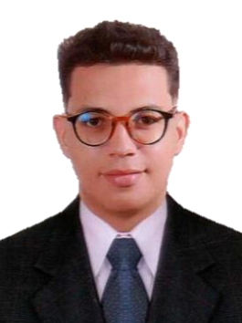

## About

I am Msc. student structural engineering at [Universidad del Norte](https://www.uninorte.edu.co/), Barranquilla, Colombia. Currently, I am working on the Colombian Seismic Risk Model and on assessing risk variation when using alternative intensity measures, such as Average spectral acceleration, AvgSA, under the supervision of Professor [Carlos Arteta](https://scholar.google.es/citations?user=t-xHI9oAAAAJ&hl=es&oi=ao). My research interests include seismic hazard, seismic risk, and risk in masonry and reinforced concrete structures.  
You can contact me by email.

## Research

1. Estimation of exposure model in cities of the Colombian Caribbean such as Barranquilla, Soledad, and Valledupar.
2. Estimation of seismic risk in cities of the Colombian Caribbean such as Barranquilla, Soledad, Valledupar, and Santa Marta.
3. Fatigue analysis of welded wire mesh used in Colombian construction.

## Publications

### Conference Papers

1. Gomez, D., Orjuela, J., Rivera, J., **Caballero, J.**, varcarcel, J., Arteta, C., Cantillo, V., Coronell, G. (2022, 15-17 de junio). Development of a seismic exposure model of cities in the caribbean of Colombia. Case: Soledad, Atlantico. X Congreso Nacional de Ingenieria Sísmica, Bogota, Colombia.

### Technical Report

1. Miranda, E., V. Abuchar, S. Alcocer, S. Aldea, J. Álvarez, J. Archbold, O. Arroyo, C. Arteta, E. Ballinas, D. Benavides, C. Blandón, M. Bravo, **J. Caballero**, J. Carrillo, C. Cruz, U. Espinoza, P. Gil, H. Guerrero, S. Gunay, P. Heresi, C. Lubin, J. Mayoral, S. Miranda, C. Pájaro, C. Piscal, J. Rivera, V. Rodríguez, A. Urango, J. Vargas, L. Velasco. (2022) “PRELIMINARY VIRTUAL RECONNAISSANCE REPORT (PVRR)”, in AQUILA, MICHOACÁN, MEXICO SEPTEMBER 19, 2022, Mw 7.6 EARTHQUAKE. [DesignSafe-CI](https://www.designsafe-ci.org). [https://doi.org/10.17603/ds2-sbcj-nx44 v1](https://www.designsafe-ci.org/data/browser/public/designsafe.storage.published/PRJ-3708/#details-2184907380584214035-242ac118-0001-012)

Copyright ® 2024, webpage made with [RStudio](https://posit.co/products/open-source/rstudio/) and [Quarto](https://quarto.org/).